# Local Projections Difference-in-Differences

Alexander Cardazzi

2024-06-25

## Getting Started

Please see the working paper on which this package is based [here (Dube et al., 2023)](https://www.nber.org/papers/w31184).

To install and load this package, use the following code:

```r
if(!"devtools" %in% installed.packages()) install.packages("devtools")
if(!"lpdid" %in% installed.packages()) devtools::install_github("alexCardazzi/lpdid")
library("lpdid")
```

## A Simple 2x2 DiD Example

To begin, consider a simple 2x2 DiD where treatment begins at $t = 31$. Only twenty out of fifty units get treated, and the treatment dynamics cause the outcome variable to increase linearly with time. Below, the outcome is averaged by time and whether the unit receives treatment at some point.

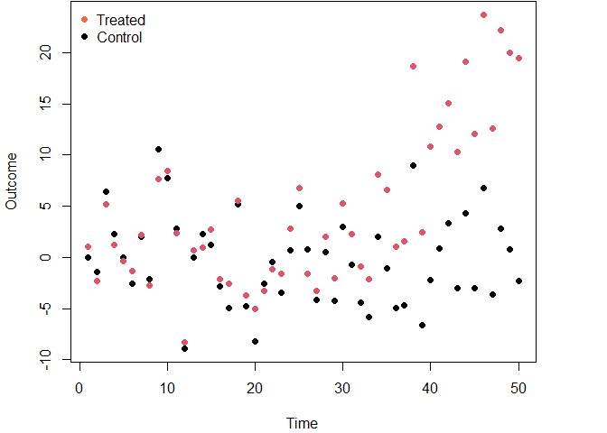

```r
library("fixest")

set.seed(757)
I <- 50; T <- 50; N <- I * T
data.frame(id = rep(1:I, each = T),
           t = rep(1:T, I),
           e = rnorm(N, 0, 4)) -> df
unit_FE <- rnorm(I, 0, 4)
time_FE <- rnorm(T, 0, 4)
df$treated <- ifelse(df$id < 21, 1, 0)
df$time_til <- ifelse(df$treated == 1, df$t - 30, -1)
df$treat_status <- ifelse(df$treated == 1 & df$t == 30, 1, 0)
df$y <- df$e + unit_FE[df$id] + time_FE[df$t] + ifelse(df$id < 21 & df$t > 30, df$t - 30, 0)
aggregate(df$y, list(df$t, df$treated), mean) -> tmp
par(mar = c(4.1, 4.1, .1, 4.1))
plot(tmp$Group.1, tmp$x, col = tmp$Group.2 + 1, pch = 19,
     xlab = "Time", ylab = "Outcome")
legend("topleft", legend = c("Treated", "Control"),
       bty = "n", pch = 19, col = c("tomato", "black"))
```

In the most simple of cases, LP-DiD and TWFE preform very similarly. Of course, TWFE is not biased in this setting, so we observe nearly identical parameter estimates (and standard errors). The important arguments for `lpdid()` are the following:

- `df`: The analysis dataset.
- `window`: This is the pre- and post-period lengths in terms of time. Importantly, the first value must be negative and the second must be positive.
- `y`: The name of the outcome variable.
- `unit_index`, `time_index`: unit and time indices. For example, if the data is state-by-year, this is where you would input these names.
- `treat_status`: This should be a vector equal to one for the time period a unit is treated. Never-treated units will have all zeros for this vector.

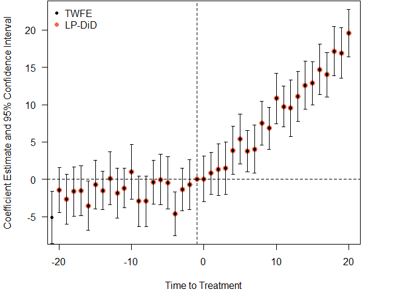

```r
lpdid(df, window = c(-20, 20), y = "y",
      unit_index = "id", time_index = "t",
      treat_status = "treat_status") -> reg
feols(y ~ i(time_til, treated, -1) | id + t, data = df) -> twfe

par(mar = c(4.1, 4.1, .1, 4.1))
plot_lpdid(reg, col = "tomato", cex = 1.3)
iplot(twfe, add = TRUE)
legend("topleft", legend = c("TWFE", "LP-DiD"),
       col = c("black", "tomato"), pch = c(20, 19), bty = "n")
```

## Staggered (Exogenous) Treatment Timing

If you are reading this, it is likely that you are aware that TWFE estimates are potentially biased depending on treatment timing and dynamics. In Dube et al. (2023), the authors simulate two sets of data: one where treatment timing is exogenous and the other where it is endogenous. First, LP-DiD is applied to the data where treatment is exogenous.

`lpdid` has a built-in function to replicate (as closely as possible) the simulations in Dube et al. (2023).[^1] Using this, we estimate TWFE and LP-DiD models in addition to plotting the “true” average beta values.

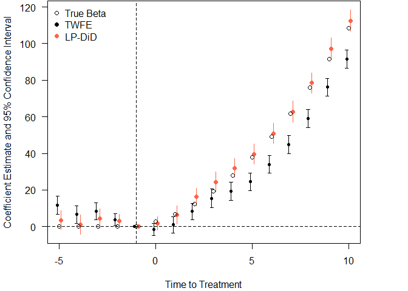

```r
df <- genr_sim_data(exogenous_timing = TRUE, 789)

twfe1 <- feols(y ~ i(rel_time, ever_treat, -1) | i + t, data = df)

lpdid1 <- lpdid(df, window = c(-5, 10), y = "y",
                unit_index = "i", time_index = "t",
                treat_status = "treat_status")

par(mar = c(4.1, 4.1, .1, 4.1))
plot_lpdid(lpdid1, col = "tomato", x.shift = 0.1)
iplot(twfe1, add = TRUE, x.shift = -0.1)
points(aggregate(df$beta[df$ever_treat == 1],
                 list(df$rel_time[df$ever_treat == 1]), mean))
legend("topleft", c("True Beta", "TWFE", "LP-DiD"), bty = "n",
       pch = c(1, 19, 19), col = c("black", "black", "tomato"))
```

## Staggered (Endogenous) Treatment Timing

For endogenous treatment timing, the main idea is that treatment is more likely following a large negative shock. See page 28 of the paper for more details on this. However, given this, we can include a lag of the outcome variable into the model. Below, four event studies are plotted: TWFE and LP-DiD, both with and without a lag of the outcome.

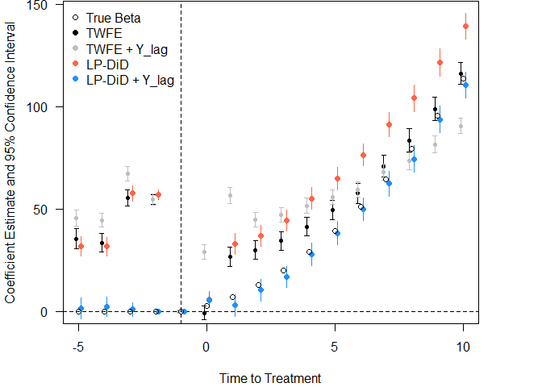

```r
df <- genr_sim_data(exogenous_timing = FALSE, 789)
# The returned "df" is a pdata.frame, so lag() works in a panel setting.
df$lag_y <- lag(df$y, 1)
twfe0 <- feols(y ~ i(rel_time, ever_treat, -1) | i + t, data = df)
twfe1 <- feols(y ~ lag_y + i(rel_time, ever_treat, -1) | i + t, data = df)
lpdid0 <- lpdid(df, window = c(-5, 10), y = "y", outcome_lags = 0,
                unit_index = "i", time_index = "t", treat_status = "treat_status")
lpdid1 <- lpdid(df, window = c(-5, 10), y = "y", outcome_lags = 1,
                unit_index = "i", time_index = "t", treat_status = "treat_status")
par(mar = c(4.1, 4.1, .1, 4.1))
plot_lpdid(lpdid0, col = "tomato", x.shift = 0.1)
plot_lpdid(lpdid1, col = "dodgerblue", x.shift = 0.1, add = TRUE)
iplot(twfe0, add = TRUE, x.shift = -0.1)
iplot(twfe1, add = TRUE, x.shift = -0.1, col = "gray")
points(aggregate(df$beta[df$ever_treat == 1], list(df$rel_time[df$ever_treat == 1]), mean))
legend("topleft", bty = "n",
       c("True Beta", "TWFE", "TWFE + Y_lag", "LP-DiD", "LP-DiD + Y_lag"),
       pch = c(1, 19, 19, 19, 19),
       col = c("black", "black", "gray", "tomato", "dodgerblue"))
```

## Andrew Baker’s Simulated Dataset

Andrew Baker created a simulated data (found [here](https://github.com/scunning1975/mixtape/)) in order to demonstrate the potential pit falls of using TWFE in a setting with staggered treatment timing and temporal treatment dynamics. Below is an aggregated version of this data where average outcomes are calculated by time and treatment group.

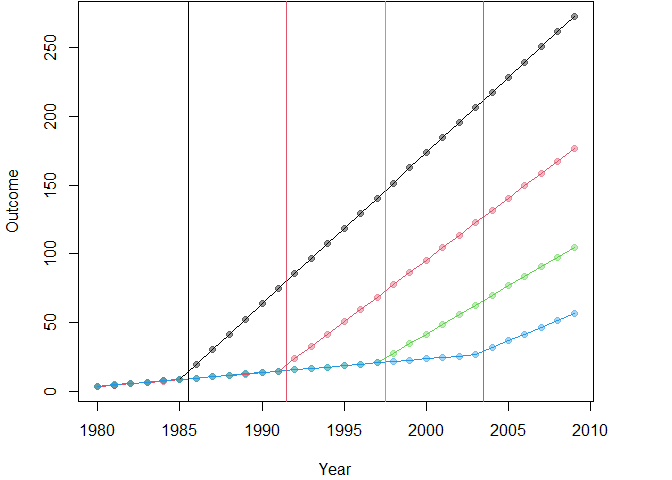

```r
baker <- haven::read_dta('https://github.com/scunning1975/mixtape/raw/master/baker.dta')
baker$treated <- ifelse(baker$treat_date > 0, 1, 0)
baker$treat_status <- ifelse(baker$treat_date == baker$year, 1, 0)

tmp <- aggregate(list(y = baker$y),
                 list(year = baker$year,
                      group = baker$group),
                 mean)
par(mar = c(4.1, 4.1, .1, 4.1))
plot(tmp$year, tmp$y, pch = 19,
     col = scales::alpha(tmp$group, .4),
     xlab = "Year", ylab = "Outcome")
lines(tmp$year[tmp$group == unique(tmp$group)[1]],
      tmp$y[tmp$group == unique(tmp$group)[1]],
      col = tmp$group[tmp$group == unique(tmp$group)[1]])
lines(tmp$year[tmp$group == unique(tmp$group)[2]],
      tmp$y[tmp$group == unique(tmp$group)[2]],
      col = tmp$group[tmp$group == unique(tmp$group)[2]])
lines(tmp$year[tmp$group == unique(tmp$group)[3]],
      tmp$y[tmp$group == unique(tmp$group)[3]],
      col = tmp$group[tmp$group == unique(tmp$group)[3]])
lines(tmp$year[tmp$group == unique(tmp$group)[4]],
      tmp$y[tmp$group == unique(tmp$group)[4]],
      col = tmp$group[tmp$group == unique(tmp$group)[4]])
abline(v = unique(baker$treat_date)-0.5, col = 1:4)
```

When estimating a simple TWFE model, the following is the estimate generated by OLS:

```r
feols(y ~ treat | id + year, data = baker)
```

```
#> OLS estimation, Dep. Var.: y
#> Observations: 30,000
#> Fixed-effects: id: 1,000,  year: 30
#> Standard-errors: Clustered (id)
#>       Estimate Std. Error  t value  Pr(>|t|)
#> treat -6.69019   0.670213 -9.98218 < 2.2e-16 ***
#> ---
#> Signif. codes:  0 '***' 0.001 '**' 0.01 '*' 0.05 '.' 0.1 ' ' 1
#> RMSE: 29.1     Adj. R2: 0.803436
#>              Within R2: 0.003954
```

Of course, the treatment effect is surely non-negative. Below, we estimate TWFE, Sun & Abraham, and LP-DiD models. Here, just to exemplify another feature of the package, one can re-weight the regression to obtain an ATT rather than a VWATT. Here, the results are nearly identical to the estimates via Sun & Abraham. Also, note that the window (`(-20, 20)`) is wider than what is plotted `(-17, 17)`. This is a feature since the FEs and the treatment variable are perfectly colinear outside what is returned.

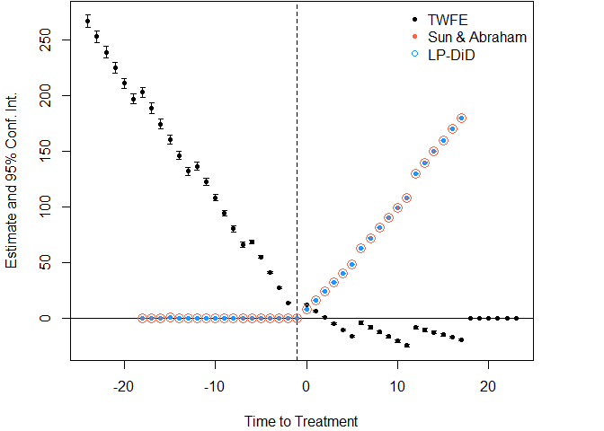

```r
res_naive = feols(y ~ i(time_til, treated, ref = -1) |
                    id + year,
                  baker, cluster = ~state)

res_cohort = feols(y ~ sunab(treat_date, year) | id + year,
                   baker[baker$year<2004,],
                   cluster = ~state)

lpdid(df = baker, window = c(-20, 20), y = "y",
      unit_index = "id", time_index = "year",
      treat_status = "treat_status", reweight = TRUE) -> reg

par(mar = c(4.1, 4.1, .1, 4.1))
iplot(res_naive, col = "black", grid = F,
      xlab = "Time to Treatment", main = "")
iplot(res_cohort, col = "dodgerblue", add = TRUE)
plot_lpdid(reg, add = TRUE, col = "tomato", pch = 1, cex = 1.5)
legend("topright", col = c("black", "tomato", "dodgerblue"),
       pch = c(20, 20, 1), bty = "n",
       legend = c("TWFE", "Sun & Abraham", "LP-DiD"))
```

It is also possible to pool together the treatment effects and get standard errors using the `lpdid` function.

```r
lpdid(df = baker, window = c(-20, 20), y = "y",
      unit_index = "id", time_index = "year",
      treat_status = "treat_status", reweight = TRUE, pooled = TRUE) -> reg
reg$coeftable
```

```
#>    Estimate Std. Error  t value Pr(>|t|)
#> 21 90.09827  0.6896807 130.6377        0
```

## Non-Absorbing Treatment

This is under construction…

## Informal Changelog

This is the first iteration of this package. So, of course, there are some known (and surely many unknown) bugs. Some of them are as follows:

- Reweighting does not currently work as intended for the non-absorbing estimation. This, as well as other portions of the non-absorbing estimation, are still being worked on. **This has been fixed in Version 0.3.0.**
- Pooling the effect across post-periods does not always work as intended when using controls or outcome lags as regressors. **This has been fixed in Version 0.2.0.**
- **Version 0.4.0** has been updated to:
  - Fix a bug that caused too-large p-values when effects were negative
  - Change the way controls are input into the function. Now, you should use *formulas* instead of character vectors to supply controls. In addition, controls can be time invariant or time varying.
  - Allow the user to specify the level of clustering.
- **Version 0.5.0** has been updated to:
  - Add in support for FEs.
  - Change the requirement for “rel_time” to “treat_status”.
- **Version 0.6.0** has been updated to:
  - Fix a bug that caused `NA` estimates with `composition_correction = TRUE`.
  - Change some argument names to match the `STATA` version of the same function. Additional changes are in the works to make these two packages as similar as possible. Old argument names will continue to work.

Please direct any questions or comments to Alex and all complaints to Zach.

[^1]: This function is under development. Currently, the parameters are fixed, so the only options are the exogeneity of the treatment timing and the random number seed. The intention is to allow for full control over the parameters so users can experiment.